# Well Drilling Data Analysis and Prediction

Analyzing data recorded by measurement tools and log sensors of the drilling environment for Utah Forge well 58-32 for a geothermal reservoir characteristics study. A prediction is made applicable on new data, for recognizing Rate Of Penetration (ROP), by using numerical correlations between ROP and applied drilling parameters.

## Reading data

2 csv files, one as a raw huge data, and another as a processed version

Drilling data of the well with starting depth of 25 meters and the stop depth was 2.3 km. This data contains information on the nature of the subsurface materials and performance of the drilling rig and drilling bits, including;

- Rate of Penetration (ROP)
- Weight on the drilling bit
- Temperatures of the mud in/out
- Pit of mud volume
- Pump pressure for pushing mud through bit nozzles
- Hook-load of the drilling pipe
- Applied torque
- Bit rotating speed
- Mud flow rate in/out
- Well Head pressure
- Levels of H2S on the floor, well head level, and down the pit.

## Cleaning

- Pump 1 and Pump 2 at first DataFrame tends to 0 at most times as described, so they will be replaced with the Pump Pressure present in second DataFrame.
- Block height, and Bit depth in the 1st data represent similar but negative relationship with the height - with many negative values - so they will be neglected.
- We have duplicated columns with the same feature meaning, but with different units. We shall keep SI units and remove imperial units.
- Based on the data information, so we have no missing values
- We have 154 duplicated rows on 1st dataframe, and 30 on 2nd dataframe that need to be removed
- We have two dataframes that complement each other, so both shall be merged

## Visualizations

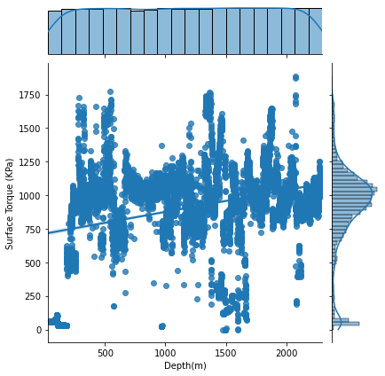

It seems like going more deeply, increases the torque required applied on the surface

[output not shown]

[output cut: 28083 more lines]

[output not shown]

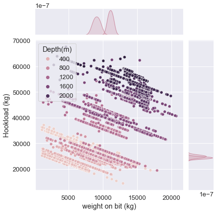

## ETL

Removing outliers

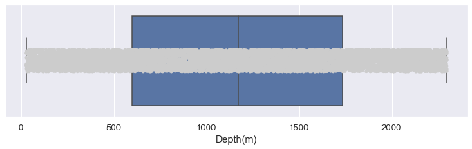

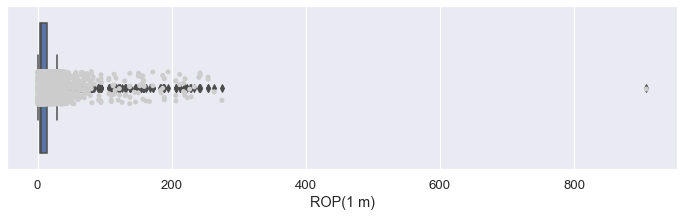

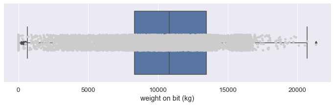

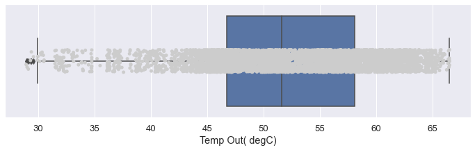

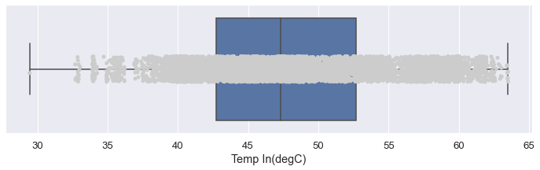

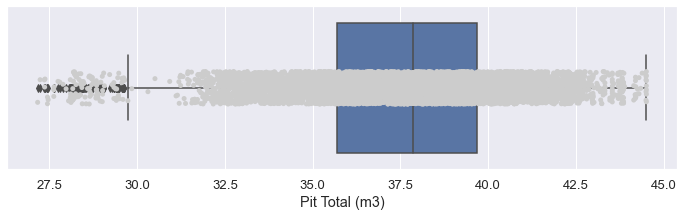

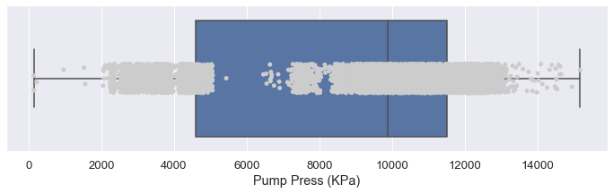

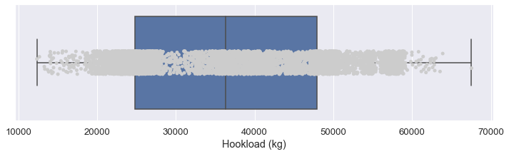

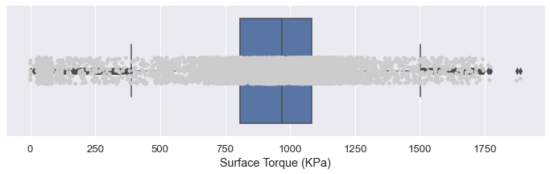

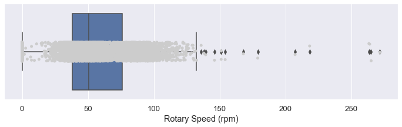

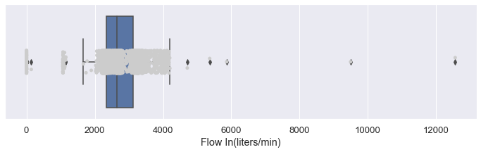

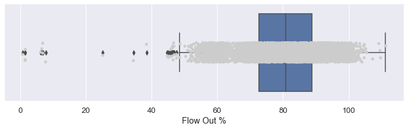

[4 more figures not shown]

## ML (Supervised Learning)

Applying Supervised Learning using Regression methods, and measuring scores for each.

```
Using: LR
Train Accuracy: 0.5574351166140177
Test Accuracy: 0.5819975668508626
--------------------

Using: KNN
Train Accuracy: 0.8721557268483742
Test Accuracy: 0.8523838121518887
--------------------

Using: SVM
Train Accuracy: 0.702823107583195
Test Accuracy: 0.7127907798454236
--------------------

Using: DT
Train Accuracy: 1.0
Test Accuracy: 0.8496262366686907
--------------------

Using: RF
Train Accuracy: 0.9809090340199157
Test Accuracy: 0.8762624419623718
--------------------

Using: XGB
Train Accuracy: 0.9248255440392251
Test Accuracy: 0.8613115183914319
--------------------


Processing duration (hours): 0:00:08.466311
```

We can conclude that **Random Forest Regressor** model is the best to use

*The Model obtained, in addition to the scaler used, are to be saved on external files for usage on any application. Then, a test can be applied using any smaple data with the same shape, thus obtaining a ROP prediction.*

## ML (Unsupervised)

Let's detect categories of data representing different formations of the ground. This can help in detecting ground parameters for future work on adjacent area.

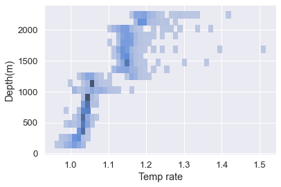

The distribution of the temperature differences (in/out) along the well depth has been found related positively.

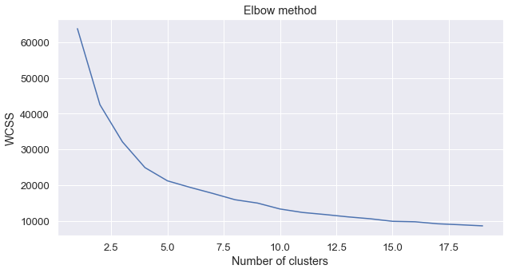

KMeans method result can deduce 5 clusters to use.  
Let's also use Heirarchical Clustering with Dendrogram to verify results

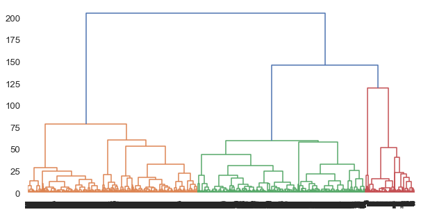

Agglomorative clustering can deduce 5 clusters to use  
So we will proceed with 5 clustering

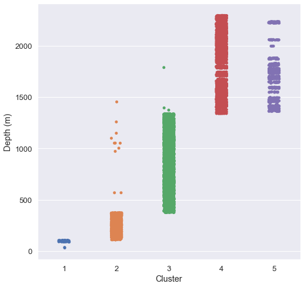

So Clusters are strongly related to the depth level of the well, which can be considered as an indicator for the same.

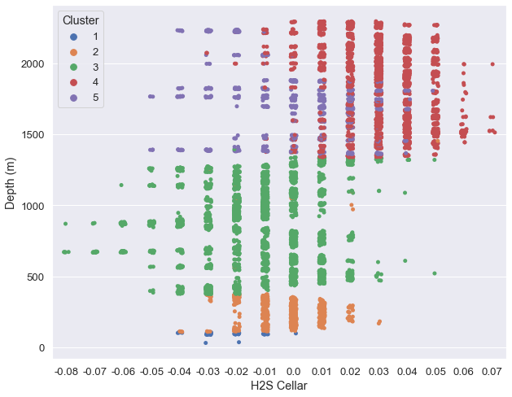

This observation tells that at specific clusters, H2S levels may be affected with a scale.

In order to **Enhance this prediction** experience

- Different more data sources to be added e.g. for multiple wells in many locations, under different characteristics.
- Additional geological data for the ground formations to be present under the study.